# guessing-cliff-d-abschluesse_sc

Eine Studie vergleicht den höchsten Bildungsabschluss zweier Gruppen.

> Schätzen Sie $\text{Cliff's } d = \frac{\#(A_i > B_i) - \#(A_i < B_i)}{\#A \cdot \#B}$

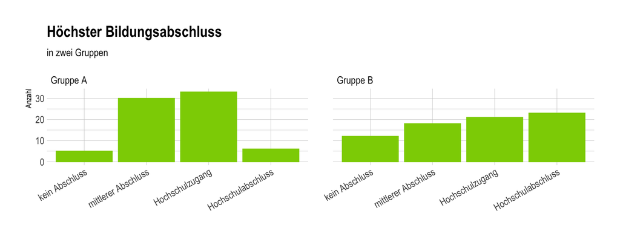

Eine Studie vergleicht den höchsten Bildungsabschluss zweier Gruppen.

> Schätzen Sie $\text{Cliff's } d = \frac{\#(A_i > B_i) - \#(A_i < B_i)}{\#A \cdot \#B}$

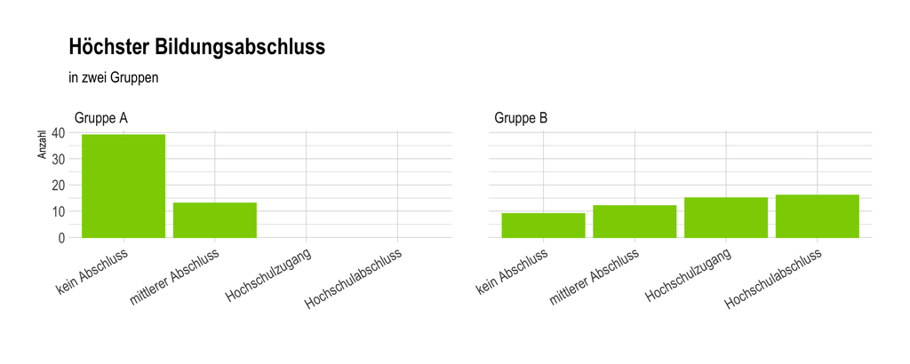

Eine Studie vergleicht den höchsten Bildungsabschluss zweier Gruppen.

> Schätzen Sie $\text{Cliff's } d = \frac{\#(A_i > B_i) - \#(A_i < B_i)}{\#A \cdot \#B}$

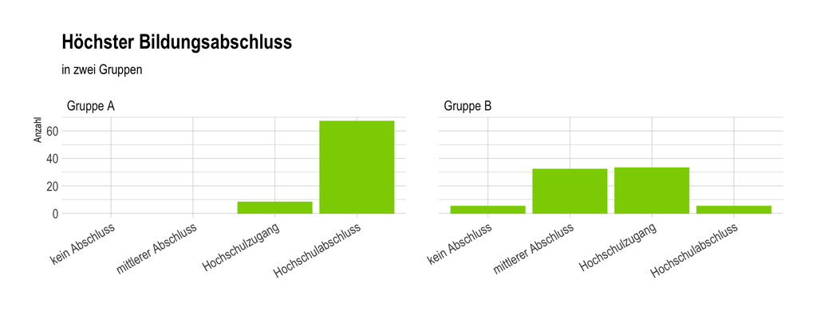

Eine Studie vergleicht den höchsten Bildungsabschluss zweier Gruppen.

> Schätzen Sie $\text{Cliff's } d = \frac{\#(A_i > B_i) - \#(A_i < B_i)}{\#A \cdot \#B}$

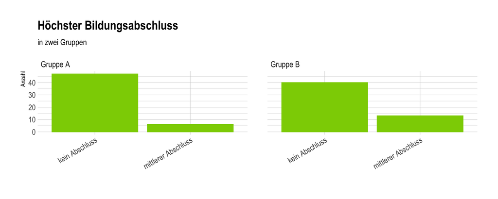

Eine Studie vergleicht den höchsten Bildungsabschluss zweier Gruppen.

> Schätzen Sie $\text{Cliff's } d = \frac{\#(A_i > B_i) - \#(A_i < B_i)}{\#A \cdot \#B}$

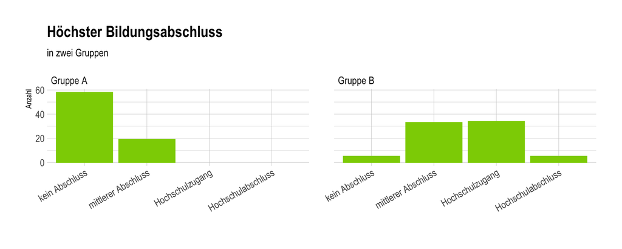

Eine Studie vergleicht den höchsten Bildungsabschluss zweier Gruppen.

> Schätzen Sie $\text{Cliff's } d = \frac{\#(A_i > B_i) - \#(A_i < B_i)}{\#A \cdot \#B}$

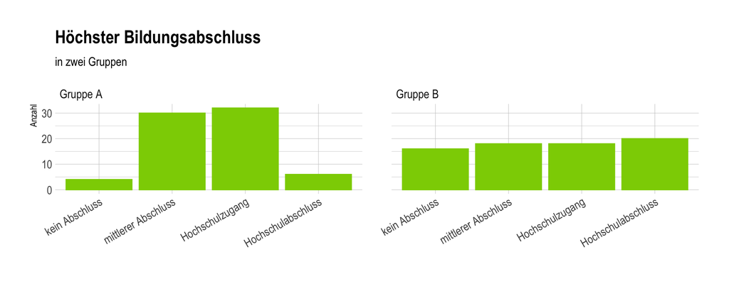

Eine Studie vergleicht den höchsten Bildungsabschluss zweier Gruppen.

> Schätzen Sie $\text{Cliff's } d = \frac{\#(A_i > B_i) - \#(A_i < B_i)}{\#A \cdot \#B}$

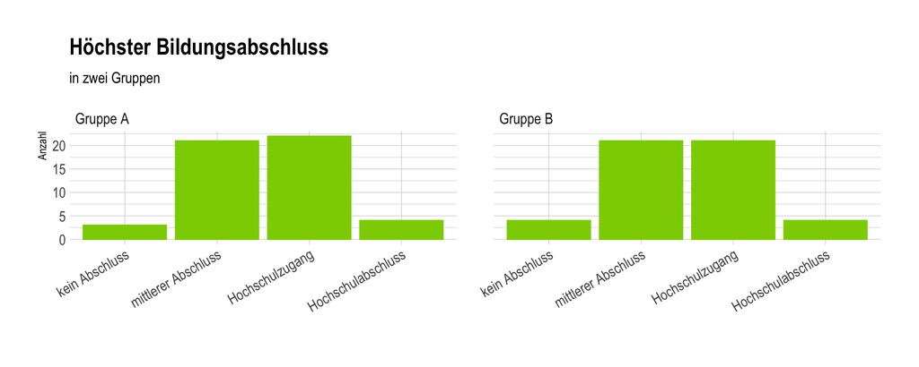

Eine Studie vergleicht den höchsten Bildungsabschluss zweier Gruppen.

> Schätzen Sie $\text{Cliff's } d = \frac{\#(A_i > B_i) - \#(A_i < B_i)}{\#A \cdot \#B}$

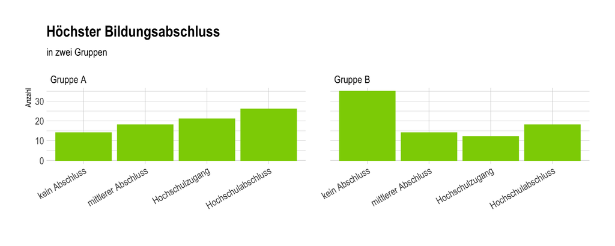

Eine Studie vergleicht den höchsten Bildungsabschluss zweier Gruppen.

> Schätzen Sie $\text{Cliff's } d = \frac{\#(A_i > B_i) - \#(A_i < B_i)}{\#A \cdot \#B}$

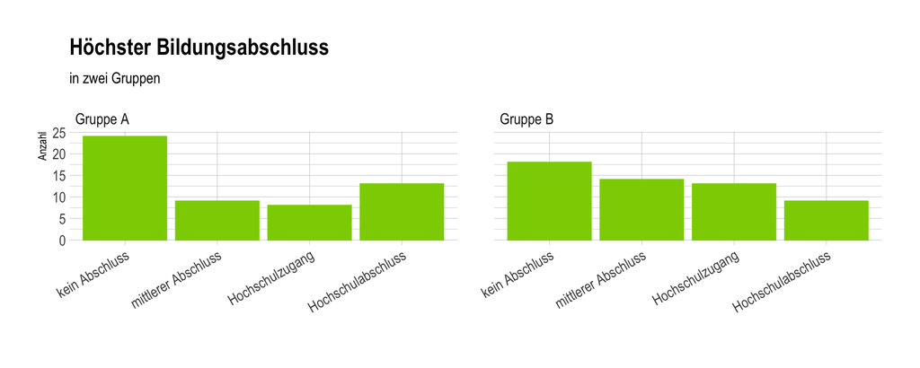

Eine Studie vergleicht den höchsten Bildungsabschluss zweier Gruppen.

> Schätzen Sie $\text{Cliff's } d = \frac{\#(A_i > B_i) - \#(A_i < B_i)}{\#A \cdot \#B}$

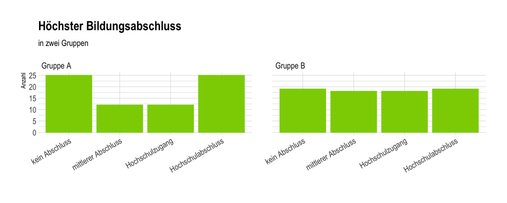

Eine Studie vergleicht den höchsten Bildungsabschluss zweier Gruppen.

> Schätzen Sie $\text{Cliff's } d = \frac{\#(A_i > B_i) - \#(A_i < B_i)}{\#A \cdot \#B}$

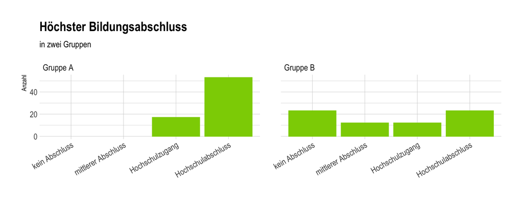

Eine Studie vergleicht den höchsten Bildungsabschluss zweier Gruppen.

> Schätzen Sie $\text{Cliff's } d = \frac{\#(A_i > B_i) - \#(A_i < B_i)}{\#A \cdot \#B}$

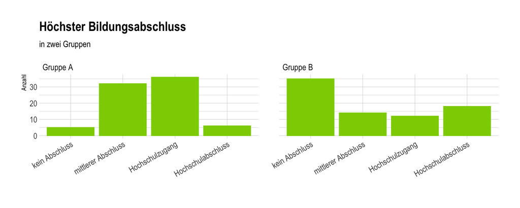

Eine Studie vergleicht den höchsten Bildungsabschluss zweier Gruppen.

> Schätzen Sie $\text{Cliff's } d = \frac{\#(A_i > B_i) - \#(A_i < B_i)}{\#A \cdot \#B}$

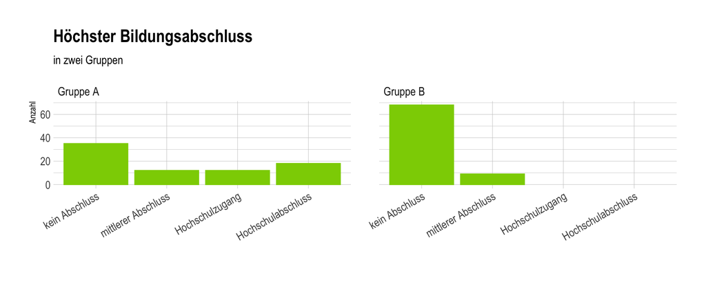

Eine Studie vergleicht den höchsten Bildungsabschluss zweier Gruppen.

> Schätzen Sie $\text{Cliff's } d = \frac{\#(A_i > B_i) - \#(A_i < B_i)}{\#A \cdot \#B}$

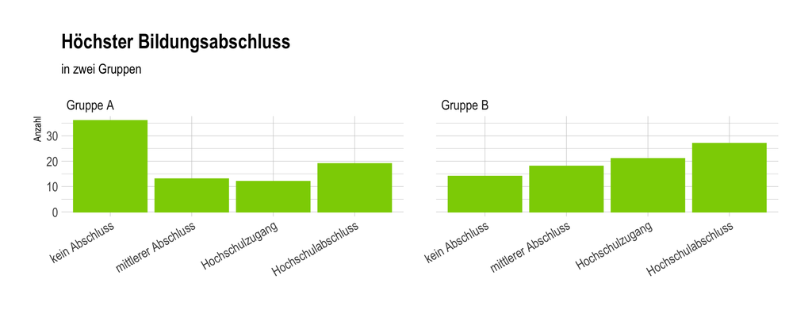

Eine Studie vergleicht den höchsten Bildungsabschluss zweier Gruppen.

> Schätzen Sie $\text{Cliff's } d = \frac{\#(A_i > B_i) - \#(A_i < B_i)}{\#A \cdot \#B}$

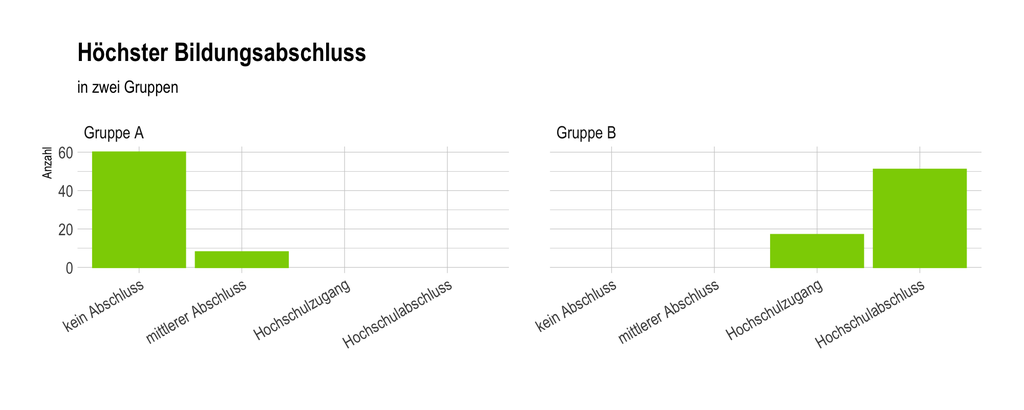

Eine Studie vergleicht den höchsten Bildungsabschluss zweier Gruppen.

> Schätzen Sie $\text{Cliff's } d = \frac{\#(A_i > B_i) - \#(A_i < B_i)}{\#A \cdot \#B}$

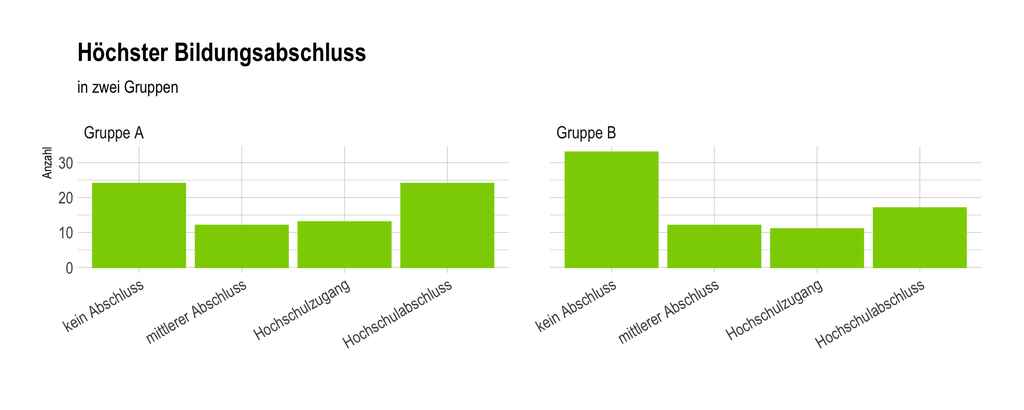

Eine Studie vergleicht den höchsten Bildungsabschluss zweier Gruppen.

> Schätzen Sie $\text{Cliff's } d = \frac{\#(A_i > B_i) - \#(A_i < B_i)}{\#A \cdot \#B}$

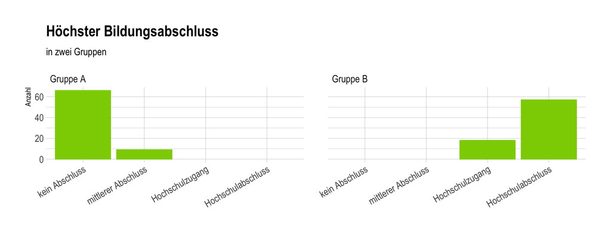

Eine Studie vergleicht den höchsten Bildungsabschluss zweier Gruppen.

> Schätzen Sie $\text{Cliff's } d = \frac{\#(A_i > B_i) - \#(A_i < B_i)}{\#A \cdot \#B}$

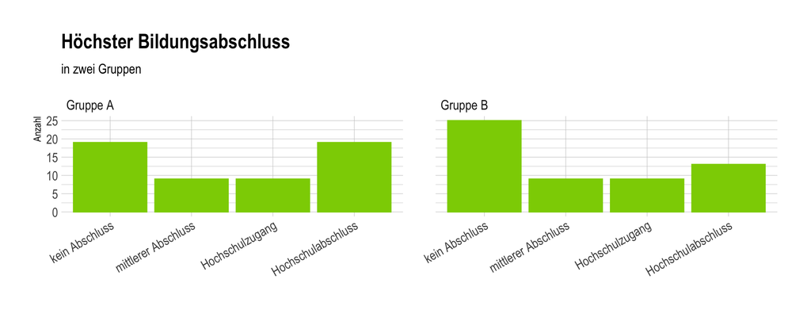

Eine Studie vergleicht den höchsten Bildungsabschluss zweier Gruppen.

> Schätzen Sie $\text{Cliff's } d = \frac{\#(A_i > B_i) - \#(A_i < B_i)}{\#A \cdot \#B}$

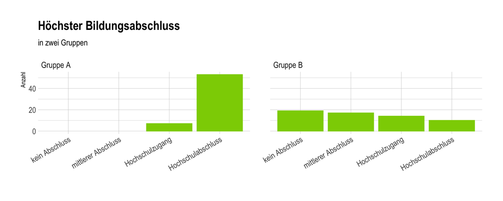

Eine Studie vergleicht den höchsten Bildungsabschluss zweier Gruppen.

> Schätzen Sie $\text{Cliff's } d = \frac{\#(A_i > B_i) - \#(A_i < B_i)}{\#A \cdot \#B}$

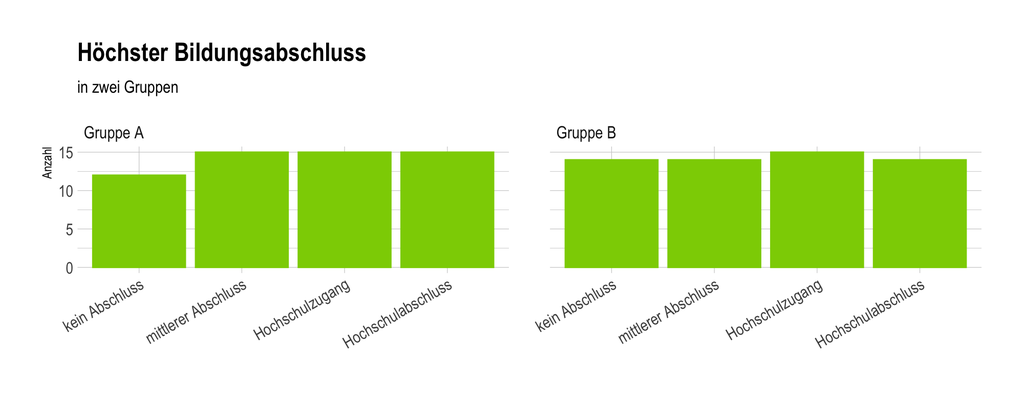